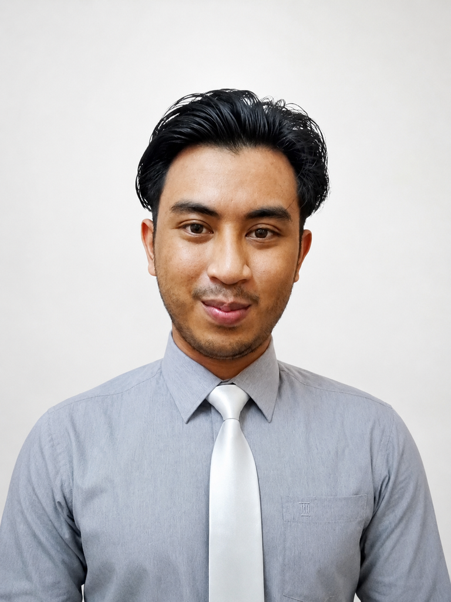

# Muhammad Mustaqim

- Alor Gajah, Melaka, Malaysia | 📞 [**+6011-12891989**](https://wa.me/601112891989) | ✉️ **mus270897@gmail.com**
- 🔗 [**LinkedIn**: https://www.linkedin.com/in/muhammad-mustaqim-samsudin-2b0bb0300](https://www.linkedin.com/in/muhammad-mustaqim-samsudin-2b0bb0300)
- 🔗 [**Live Resume**: https://taqim2708.github.io/resume-mustaqim/](https://taqim2708.github.io/resume-mustaqim/)

# PROFESSIONAL SUMMARY

- Backend Software Engineer with 3+ years of experience building and maintaining production-grade web applications using Python (Django) and PostgreSQL.
- Specialized in backend API development, authentication, database optimization, and CI/CD automation using Docker and GitLab.
- Experienced in integrating LLM-based features into backend systems and designing scalable APIs in collaborative, remote engineering environments.
- Strong focus on performance, reliability, and clean backend architecture.

# TECHNICAL SKILLS

- **Backend:** Python, Django, FastAPI, REST API design, Authentication & Authorization (Oauth, Keycloak)
- **Database:** PostgreSQL (schema design, indexing, query optimization, migrations)
- **Frontend (supporting role):** JavaScript, React, Next.js
- **DevOps & Tools:** Docker, GitLab CI/CD, Git, Linux
- **AI Integration:** LLM integration, Model Context Protocol (MCP), LibreChat customization
- **Testing & QA:** pytest, Selenium, Playwright
- **Data & Analytics:** Python, Excel (Pivot Tables, Dashboards), SPSS

# PROFESSIONAL EXPERIENCE

## Software Developer (Backend)

V Aim Sdn Bhd | Jul 2022 – Present

- Joined as a fresh graduate and rapidly contributed to production-level backend systems within a Django-based architecture
- Developed and maintained REST APIs for core application features including authentication, data workflows, and business logic
- Maintaining and fixing Keycloak-based authentication
- Improved backend reliability by implementing automated testing suites using pytest and Selenium, reducing regression issues
- Optimized PostgreSQL queries and database structure, improving API performance and system responsiveness
- Designed and maintained CI/CD pipelines using Docker and GitLab CI, enabling consistent and reliable deployments
- Collaborated with distributed teams in an agile environment to deliver features and maintain code quality standards
- Participated in backend architecture discussions to improve scalability and long-term maintainability

# KEY PROJECTS

## AI-LMS Platform (Full-Stack + AI Integration)

- Designed and developed a scalable Learning Management System using Django backend architecture
- Built RESTful APIs for authentication, course management, and core platform workflows
- Optimized database performance through indexing and query improvements for high-traffic API endpoints
- Implemented CI/CD pipelines using Docker and GitLab, reducing manual deployment errors and improving release consistency
- Integrated LLM-based features using Model Context Protocol (MCP) to enable AI-assisted system interactions
- Customized LibreChat to support auto-login, session persistence, and embedded workflows for seamless user experience
- Contributed to backend system design decisions to ensure scalability and modularity

## Graphistry

**Tech Stack**: React.js, Django, PostgreSQL, Docker, Dockerfile, YAML, Keycloak, pytest, Selenium, RxJS

- Contributed to the development of Graphistry, a production-grade platform for a US-based data visualization company serving enterprise and government clients
- Worked across both backend (Django) and frontend (React.js) components to deliver full-stack features and system improvements
- Implemented authentication and authorization workflows using Keycloak, improving security and access control management
- Developed automated testing pipelines using pytest and Selenium to improve system reliability and reduce regressions
- Worked in a containerized environment using Docker and CI/CD pipelines for consistent deployment workflows
- Collaborated closely with the project lead (former Google engineer), receiving direct feedback on code quality, architecture decisions, and engineering best practices
- Gained strong experience in production-level engineering standards, code review processes, and scalable system design

## ERP Customization – International Marble Co

- Customized ERPNext workflows using Python and JavaScript to align system behavior with business requirements
- Improved internal operational efficiency by adapting system logic to real-world workflows

## AnticapteLife

- Contributed to full-stack development using Django and React
- Developed backend services and integrated frontend components

## Superfy

- Built backend services using FastAPI and DynamoDB
- Designed APIs for scalable data handling and service integration

# KEY ACHIEVEMENTS

- Improved deployment reliability through CI/CD automation using Docker and GitLab
- Delivered AI-integrated features connected to internal backend APIs
- Enhanced backend performance through database optimization and efficient API design
- Gained experience working across backend, DevOps, and AI integration domains

# ANALYTICS & RESEARCH EXPERIENCE

## MBA Research Project – Staff Satisfaction Analysis

- Conducted data collection and analysis from 118 respondents using Google Forms and Python
- Performed statistical analysis using SPSS (correlation and multiple regression)
- Identified key drivers of staff satisfaction: System Quality and Information Quality
- Provided data-driven recommendations to improve system usability and performance

# EDUCATION

## Master of Business Administration (MBA)

Universiti Teknologi MARA (UiTM) Completed Feb 2026 (Awaiting Final Results)

- Dean’s List (Semester 1)
- Focus: Business Analytics
- CGPA: 3.72

## Bachelor of Computer Science (Software Development)

Universiti Teknikal Malaysia Melaka (UTeM) 2018 – 2022

- CGPA: 3.26

## Foundation in Physical Sciences

University of Malaya 2015 – 2016

- Top 20 Students (out of 400+)
- CGPA: 3.94

⬇ Download PDF